# Capstone Milestone Report

Timothy Wilson

December 12, 2015

# Executive Summary

This document provides a brief introduction to the data downloaded as part of the Coursera Capstone Course in partnership with Swiftkey. It illustrates that the data has been downloaded, cleaned, explored and initial steps have been made to build a word prediction model.

*Please note - since this report is intended to be written for a non-data specialist manager and to be as **succint as possible**, I have hidden most of the code. If you would like to access the code, you can view the rmarkdown file on my github page here: https://github.com/Econ4ahappyworld/Capstone*

# Objectives

The objectives of this report are to: - Demonstrate that the data has been downloaded nad loaded; - provide summary statistics on the datasets; - report interesting findings arrived at so far; - generate feedback on my progress so far in creating a prediction algorithm and Shiny app.

# Data

The raw data sets are downloaded from the following link: https://d396qusza40orc.cloudfront.net/dsscapstone/dataset/Coursera-SwiftKey.zip  
These data sets are very large, so this RMarkdown document loads a previously downloaded version of the datasets that have been saved locally. The datasets are saved in four folders, each corresponding to a specific country and language - Germany in German, United States in English, Finland in Finnish and Russia in Russian.

```
## [1] "de_DE"  "en_US"  "fi_FI"  "ru_RU"  "sample"
```

*Note that the sample folder is a folder I created for my analysis, all others are the raw data*

Each folder has three data sets relating to news, twitter and blogs.  
I report the en_us folder as an example…

```
## [1] "en_US.blogs.txt"   "en_US.news.txt"    "en_US.twitter.txt"
```

### File size

As stated above, the size of each of these files is large. Here is a list of the file size of the twelve different files.

```
##  [1] 210160014 205811889 167105338  85459666  95591959  75578341 108503595
##  [8]  94234350  25331142 116855835 118996424 105182346
```

To avoid repitition, and since the I have established that all folders contain the same type of files, I report the results of my further investigation and exploratory analysis only in respect of the folder containing english files from the United States of America.

### Line count

The number of lines in the United States english **blogs** text file is:

```
## [1] 899288
```

The number of lines in the United States english **news** text file is:

```
## [1] 1010242
```

The number of lines in the United States english **twitter** text file is:

```
## [1] 2360148
```

# Exploratory data analysis

Since the data files are so big, we are going to take a one percent sample of each to conduct our exploratory analysis. We then combine them into a corpus. Note that I tried using a larger sample (ten percent and five percent) but when it came to tokenization I ran out of memory.

We now perform some basic data cleaning so that we can tokenize it and explore.

```r
en_US_corpus <- tm_map(en_US_corpus, stripWhitespace) #takes out the extra whitespace that we don't need
en_US_corpus <- tm_map(en_US_corpus, content_transformer(tolower)) #Transforms all words to lower case
en_US_corpus <- tm_map(en_US_corpus, removeWords, stopwords("english")) #removes stopwords.
en_US_corpus <- tm_map(en_US_corpus, removeNumbers) #Removes numbersI subsequently learnt you have to do this or else numbers are by far the most common "word".
en_US_corpus <- tm_map(en_US_corpus, removePunctuation)
```

## Unigram analysis

We first examine the word documents by looking at single words, in other words, a unigram analysis.

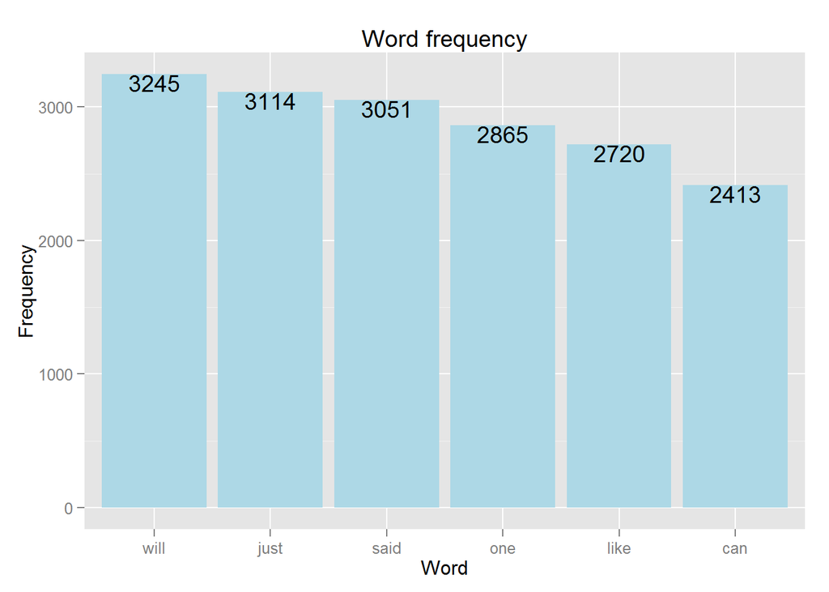

We then perform analysis of two word strings, which is otherwise known as a bigram analysis.

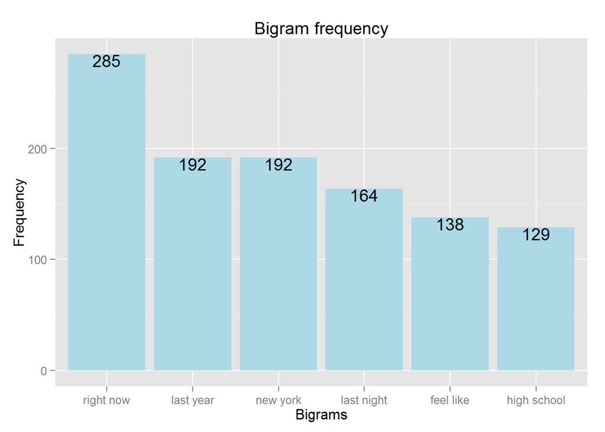

Finally, we perform analysis of three words strings, which is otherwise known as a trigram analysis.

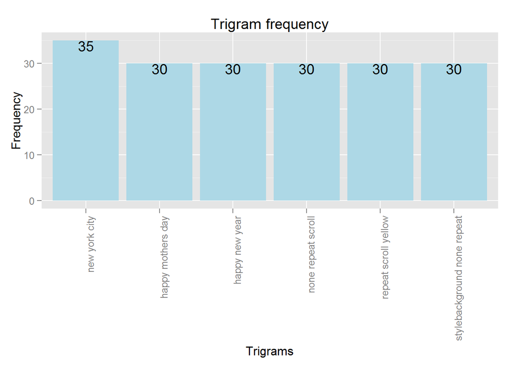

# Next steps

The ultimate goal of this work is to create a word prediction algorithm.  
Therefore, the next steps are to build a prediction algorithm that uses the knowledge we have gained above to predict the next word. At this stage, my plan is to build a tool (that will be launched online at the ShinyApps portal) that would take the words that the user has inputed, then calculate the most likely next word by using associations that we have calculated with the data above.